# Impact of Short-Snout Dragon reintroduction on Swedish Griffin abundance and spatial distribution

A report prepared for the Ministry of Magic

Allison Horst

10/31/2019

### Introduction

In 2005, after a 425 year absence, 18 captively bred Swedish Short-Snout dragons were reintroduced to their historic habitat in the Scandinavian Mountains (Potter and Granger 2019). The subsequent increase in dragon population - reaching 284 dragons in 2019 - has been closely studied and widely reported (Weasley et al. 2019). Less understood is how dragon reintroduction has impacted the homerange and abundance of the endangered Swedish Griffin. Longbottom et al. predicted that dragon predation would decimate the Swedish Griffin population and shift their range to more protected forested areas at lower elevation (Longbottom et al. 2003). To date, however, dragon impacts on Griffin range and populations have not been explored. Here, we use data collected by the Fantastic Beasts Research Team to compare pre- and post-dragon population trends and spatial shifts for Swedish Griffins.

[figure not shown]

**Figure 1.** Swedish Griffin (left) and Swedish Short-Snout Dragon (right). Credit: [Harry Potter wiki fandom](https://harrypotter.fandom.com/wiki/Main_Page).

### Data and Methods

Data for Swedish Griffin abundance and location from 1984 - 2019 were collected and provided by the Fantastic Beasts Research Team. Griffin abundance (individuals) is estimated from annual aerial counts. Griffin location (latitude, longitude) is uploaded daily from GPS-enabled collars, and used to estimate range areas (km<sup>2</sup>). For more information on collection methods and spatial information, see metadata. Habitat shifts were based on aerial observation and GPS locations, and were binned for this report as “Grassland”, “Forest” or “Exposed rock”. Mean griffin range area (km<sup>2</sup>) was compared for pre-dragon (1984 - 2004) and post-dragon (2005 - 2019) periods by two-sample t-tests ($\alpha$ = 0.05 throughout). Trends in Griffin abundance were compared before and after dragon reintroduction by linear regression. All analyses and figures were prepared using R software version 3.6.1.

### Results

#### 1. Effects of dragon reintroduction on griffin abundance

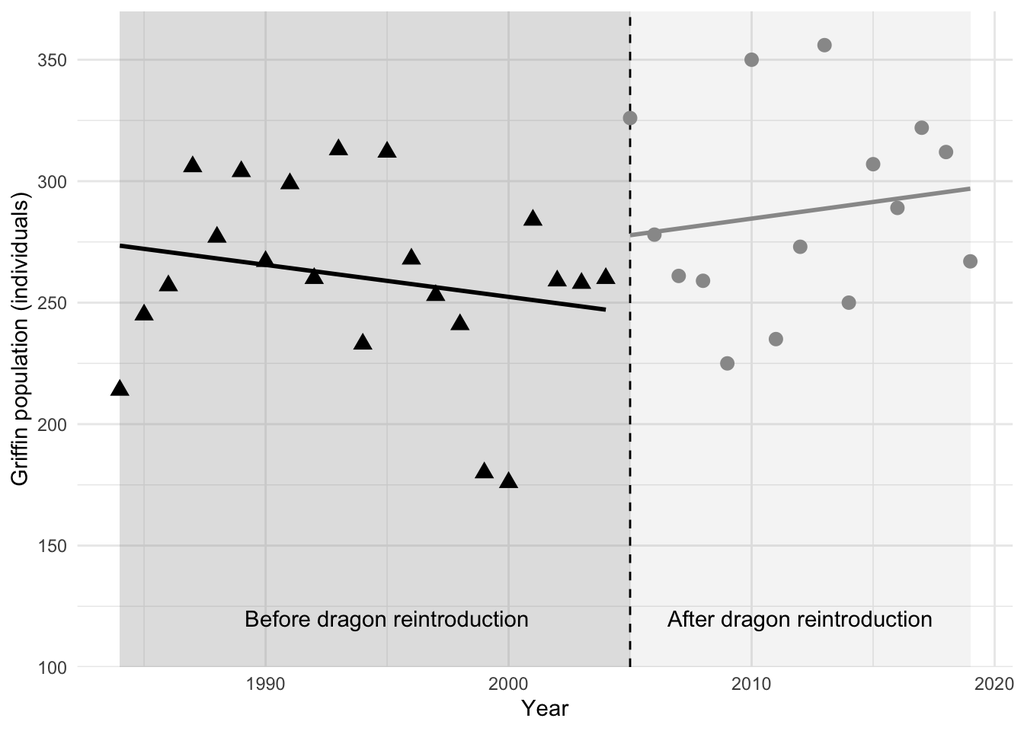

**Figure 2.** Swedish Griffin population before and after Short-Snout dragon reintroduction to the Scandinavian Mountains. Growth rates for pre-dragon griffin populations (black triangles; 1984 - 2004) and post-dragon griffin populations (gray circles; 2005 - 2019) were not significantly non-zero. Data: Fantastic Beasts Research Team.

#### 2. Griffin shifts to lower elevation forests

While Swedish Griffin populations were not reduced following dragon reintroduction, a notable shift in Griffin habitat from exposed rocky slopes and snow fields to lower elevation forests has occurred since 2005 (Figure 3).

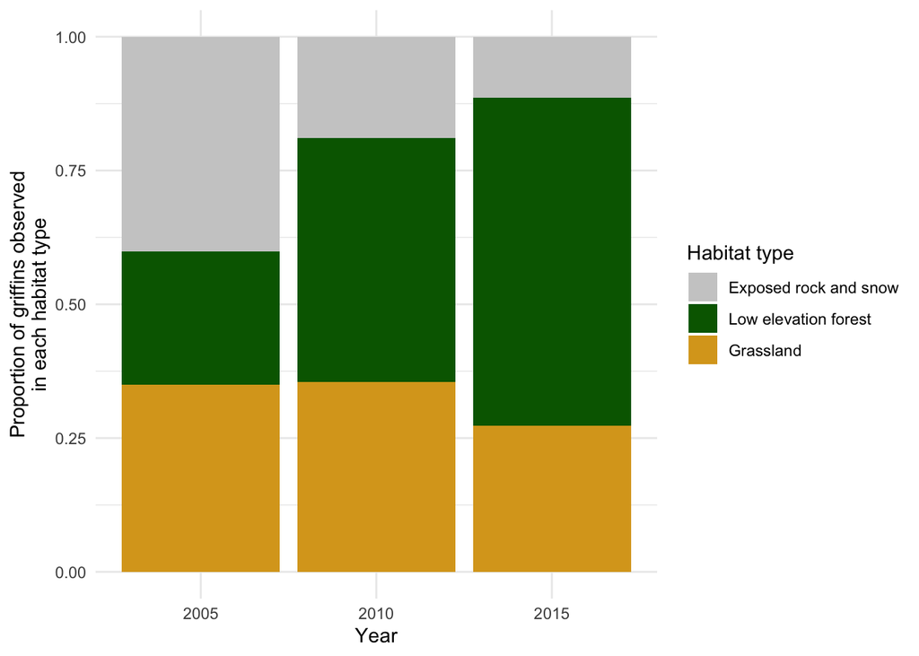

**Figure 3.** Proportions of griffins in three habitat types, 2005 - 2015. Griffin habitat (from aerial observations) was described as one of the following types: exposed rock and snow (light gray), low elevation forest (green), and grassland (gold). Total griffin counts by habitat survey year: n*<sub>2005</sub> = 354,* n*<sub>2010</sub> = 332, and* n*<sub>2015</sub> = 344. Data: Fantastic Beasts Research Team.*

The proportion of griffins in grasslands remained relatively constant from 2005 - 2015, but dramatic shifts from exposed rocky slopes and snow fields to lower elevation forests were observed over the same period. In 2005, only 24.8 % of griffins were observed in lower elevation forests, compared to 61.3% in 2015. The increase in forest dwelling griffins coincided with a 3.5-fold *decrease* in the proportion of griffins observed in higher elevation exposed rock and snow field habitats. Snape (2017) proposes that the shift toward forested areas occurs as griffins seek shelter from flying dragons.

#### 3. Impacts on griffin homerange size

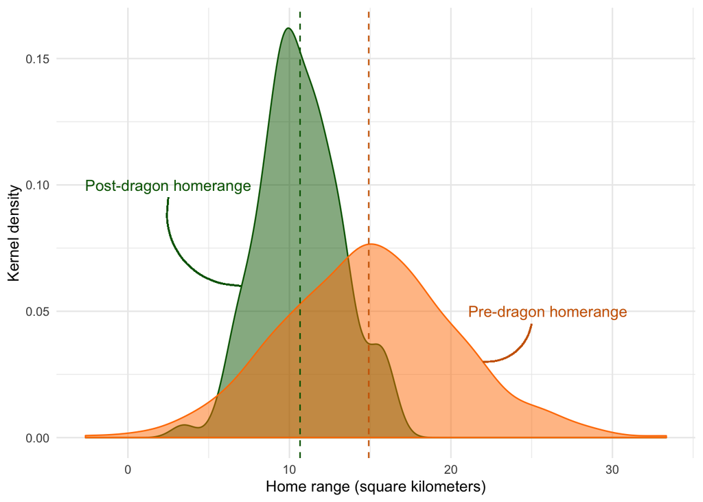

**Figure 4.** Griffin homerange size before and after dragon reintroduction. Kernel density for pre-dragon (orange; n = 418) and post-dragon (dark green; n = 211) homerange size (km<sup>2</sup>) based on GIS data from collared griffins. Means for pre- and post-dragon periods (14.9 and 10.7 km<sup>2</sup>, respectively) are shown as dashed lines with in corresponding colors. Data: Fantastic Beasts Research Team.

### Summary

- Dragon reintroduction has not caused a decrease in Swedish Griffin populations (Figure 2)
- Griffins are migrating to lower elevation forests, perhaps due to increased coverage and protection (Figure 3)
- Griffin homerange areas are significantly smaller following dragon reintroduction (Figure 4)

### References

**Dumbledore, A., A. Dementor (2013).** *Griffins limit travel in the presence of dragons.* Journal of Magical Travel 4(3): 12 - 21.

**Fantastic Beasts Research Team** (fantasticbeastsresearchwebsite.jk). *Swedish Griffin abundance and GIS data.* Accessed 11/1/2019.

**Longbottom, N., D. Malfoy, J.K. Rowling (2003).** *Modeling the future of Swedish Griffins following dragon reintroduction.* Magicological Modeling 214(1): 5 - 9.

**Potter, H. and H. Granger (2019).** *Short-snout dragon reintroduction in the Scandinavian Mountains.* Journal of Fantastic Beasts 14(2): 13 - 19.

**Snape, S. (2017).** *Shifting griffin habitat in the presence of predators.* Fantastic Predators Journal 22(9): 45 - 51.

**Weasley, R., C. Diggory, L. Voldemort (2019).** *Short-snout dragon populations since reintroduction.* Proceedings of the National Academy of Dragons 149(6): 42 - 49.